# Pset_5

AUC measures the difference between positive and negative and measures overall performance

```r
calc_auc(roc_train)
```

```
##   PANEL group      AUC
## 1     1    -1 0.845164
```

```r
calc_auc(roc_test)
```

```
##   PANEL group       AUC
## 1     1    -1 0.7648438
```

QUESTION TWO, Lasso and Ridge

2a) Load the IMDB_movies dataset and run the code below to create the testing and training datasets.

```r
set.seed(1818)

library("readr")
library("dplyr")
library("forcats")
library("rsample")
movies <- read_csv("datasets/IMDB_movies.csv")
movies_clean <- movies %>%
    mutate(budgetM = budget/1000000, grossM = gross/1000000,
        log_gross = log(gross), log_budget = log(budget), log_imdb_score = log(imdb_score)) %>%
    mutate(rating_factor = fct_lump_n(content_rating, n = 4),
        country_factor = fct_lump_n(country, n = 6), genre_factor = fct_lump_n(genres,
            n = 6))

movies_split <- initial_split(movies_clean, prop = 0.75)
movies_train <- training(movies_split)
movies_test <- testing(movies_split)
```

2b) Load the libraries glmnet and glmnetUtils installing them if necessary. Use the function cv.glmnet to fit a Ridge model against the movies_train dataset to predict log_gross. Use the following as independent variables: rating_factor, country_factor, genre_factor, log_budget, director_facebook_likes, cast_total_facebook_likes.

```r
install.packages("glmnet")
library('glmnet')
library('glmnetUtils')
independent_vars <- c("rating_factor", "country_factor", "genre_factor", "log_budget", "director_facebook_likes", "cast_total_facebook_likes")

colnames(movies_train)
```

```
##  [1] "movie_title"               "director_name"
##  [3] "gross"                     "budget"
##  [5] "country"                   "title_year"
##  [7] "imdb_score"                "language"
##  [9] "duration"                  "genres"
## [11] "content_rating"            "aspect_ratio"
## [13] "color"                     "plot_keywords"
## [15] "movie_facebook_likes"      "director_facebook_likes"
## [17] "cast_total_facebook_likes" "facenumber_in_poster"
## [19] "actor_1_facebook_likes"    "actor_1_name"
## [21] "actor_2_facebook_likes"    "actor_2_name"
## [23] "num_user_for_reviews"      "num_critic_for_reviews"
## [25] "num_voted_users"           "budgetM"
## [27] "grossM"                    "log_gross"
## [29] "log_budget"                "log_imdb_score"
## [31] "rating_factor"             "country_factor"
## [33] "genre_factor"
```

```r
X_train <- model.matrix(log_gross ~ .,
                  data = movies_train[, c(independent_vars, "log_gross")])

y_train <- movies_train$log_gross

ridge_model <- cv.glmnet(X_train, y_train, alpha = 0)

print(ridge_model)
```

```
##
## Call:  glmnet::cv.glmnet(x = X_train, y = y_train, alpha = 0)
##
## Measure: Mean-Squared Error
##
##     Lambda Index Measure     SE Nonzero
## min 0.1318   100   2.821 0.1055      19
## 1se 0.9298    79   2.914 0.1108      19
```

2c) Use the coef function over the ridge_fit object to print the coefficient matrix using the lambda of lambda.1se.

```r
coefficient_matrix <- coef(ridge_model, s = "lambda.1se")
print(coefficient_matrix)
```

```
## 21 x 1 sparse Matrix of class "dgCMatrix"
##                                             s1
## (Intercept)                       7.926338e+00
## (Intercept)                       .
## rating_factorPG                   3.296818e-01
## rating_factorPG-13                1.915208e-01
## rating_factorR                   -2.802771e-01
## rating_factorOther               -1.442184e+00
## country_factorCanada             -4.005757e-01
## country_factorFrance             -4.965140e-01
## country_factorGermany            -2.744764e-01
## country_factorUK                 -1.346993e-02
## country_factorUSA                 5.079488e-01
## country_factorOther              -9.853376e-01
## genre_factorComedy|Drama         -3.623127e-01
## genre_factorComedy|Drama|Romance  1.323775e-01
## genre_factorComedy|Romance        4.485008e-02
## genre_factorDrama                -4.753039e-01
## genre_factorDrama|Romance        -2.434889e-01
## genre_factorOther                 1.666601e-01
## log_budget                        4.866874e-01
## director_facebook_likes           2.574731e-05
## cast_total_facebook_likes         7.969907e-06
```

2d) Use the plot function over the ridge fit object. Describe the plot in your own words, including the two vertical dashed lines.

The first vertical dashed line is the Lambda.min The second vertical dashes line in the Lambda.1se This plot shows how the y-axis varies as we increase lamda with cross-validation

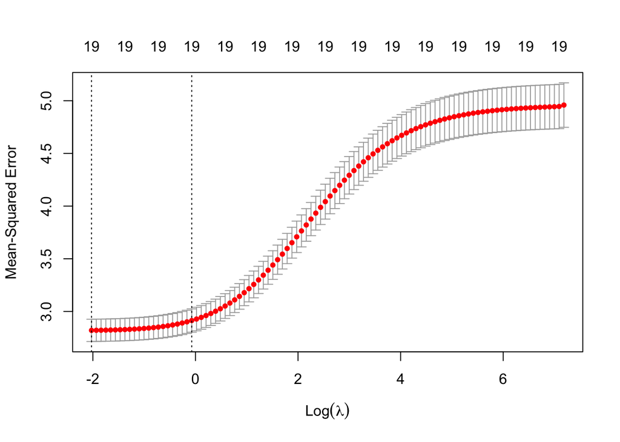

```r
plot(ridge_model)
```

2e) Estimate a lasso model using the function cv.glmnet, using the same independent and dependent variables as before, and store the model as lasso_fit

```r
install.packages("glmnet")
library(glmnet)
library(glmnetUtils)

lasso_model <- cv.glmnet(X_train, y_train, alpha = 1)
lasso_fit <- lasso_model
```

2f) Use the coef(lasso_fit) function over the lasso fit object specifying the lambda.min version of the coefficients.

```r
lasso_coefficients <- coef(lasso_fit, s = "lambda.min")
print(lasso_coefficients)
```

```
## 21 x 1 sparse Matrix of class "dgCMatrix"
##                                             s1
## (Intercept)                       4.510418e+00
## (Intercept)                       .
## rating_factorPG                   .
## rating_factorPG-13               -2.114784e-01
## rating_factorR                   -6.110424e-01
## rating_factorOther               -1.825702e+00
## country_factorCanada              .
## country_factorFrance             -2.648422e-01
## country_factorGermany             .
## country_factorUK                  3.868774e-01
## country_factorUSA                 9.119326e-01
## country_factorOther              -8.883634e-01
## genre_factorComedy|Drama         -3.831681e-01
## genre_factorComedy|Drama|Romance  1.398013e-01
## genre_factorComedy|Romance        .
## genre_factorDrama                -4.999846e-01
## genre_factorDrama|Romance        -2.582372e-01
## genre_factorOther                 2.214096e-02
## log_budget                        6.972968e-01
## director_facebook_likes           2.579036e-05
## cast_total_facebook_likes         6.375868e-06
```